# Noisy Temperatures

### Set up environment

```r
# install.packages("tidyverse")
# install.packages("moments")
# install.packages("devtolls")
# devtools::install_github("bbc/bbplot")
```

```r
library(tidyverse)
library(moments)
library(bbplot)

windowsFonts(Helvetica = "TT Arial") # for bbplot font compatability
```

### Function Definitions

#### calculation of yearly data

```r
start_yr <- 1800
end_yr <- 2100

calc_yearly_data <- function(monthly_data){

  # Count number of observations per year
  num_obs_yr <- monthly_data %>%
    mutate(Year = format(ymd(Date), "%Y")) %>%
    group_by(Year) %>%
    summarise(num_obs = n())

  # Drop years that don't have 12 months
  months_per_year <- 12
  drop_yrs <- num_obs_yr %>% filter(num_obs != months_per_year)

  # Calculate the yearly average
  yearly_data <- monthly_data %>%
    mutate(Year = format(ymd(Date), "%Y")) %>%
    filter(!Year %in% drop_yrs) %>%
    group_by(Year) %>%
    summarise(temp = mean(temp)) %>%
    mutate(Year = as.integer(Year)) %>%
    filter(Year >= start_yr) %>%
    filter(Year <= end_yr)

  # Ensure in ascending order for time series analysis
  yearly_data <- arrange(yearly_data, Year)

  return(yearly_data)
}
```

#### Printing runs test results

```r
print_runstest <- function(rt_result, rt_data){

    rt_data_rmna <- rt_data[!is.na(rt_data)]

  num_obvs_runs <- paste("Number of obversations:", rt_result[["parameter"]][["n"]])
  mean_obvs <- paste("Mean of the obversations:", format(mean(rt_data_rmna), digits=5))
  num_runs <- paste("Number of runs:", rt_result[["parameter"]][["runs"]])
  num_runs_abv <- paste("Number of runs above mean:", rt_result[["parameter"]][["n1"]])
  num_runs_blw <- paste("Number of runs below mean:", rt_result[["parameter"]][["n2"]])
  mn_runs <- paste("Mean value of stat test E(R):", format(rt_result[["mu"]], digits=3))
  sd_runs <- paste("Std. Dev. of the stat test StdDev(R):", format(sqrt(rt_result[["var"]]), digits=5))
  stat_runs <- paste("Normalized value of the stat test Z-Value:",
                     format(rt_result[["statistic"]][["statistic"]], digits=5))
  pv_runs <- paste("p-value of the stat test:", format(rt_result[["p.value"]], digits=5))

  writeLines(
    c(num_obvs_runs,
      num_runs_blw,
      num_runs_abv,
      num_runs,
      mean_obvs,
      mn_runs,
      sd_runs,
      stat_runs,
      pv_runs))
}
```

#### Printing t-test results

```r
print_ttest <- function(tt_result, tt_data){

  tt_data_rmna <- tt_data[!is.na(tt_data)]

  sample_size_tt <- paste("Sample size:", length(tt_data_rmna))
  sample_mn_tt <- paste("Sample mean:", format(mean(tt_data_rmna), digits=3))
  sample_sd_tt <- paste("Sample Std Dev:", format(sd(tt_data_rmna), digits=3))

  hyp_mn_tt <- paste("Hypothesized mean:", tt_result[["null.value"]][["mean"]])
  alt_hyp_tt <- paste("Alternative hypothesis:", tt_result[["alternative"]])
  std_err_mn_tt <- paste("Standard error of mean:", format(tt_result[["stderr"]], digits=3))
  df_tt <- paste("Degrees of freedom:", tt_result[["parameter"]][["df"]])
  stat_tt <- paste("t-test statistic:", format(tt_result[["statistic"]][["t"]], digits=3))
  pv_tt <- paste("p-value of the stat test:", format(tt_result[["p.value"]], digits=3))

  writeLines(
    c(sample_size_tt,
        sample_mn_tt,
        sample_sd_tt,
        hyp_mn_tt,
        alt_hyp_tt,
        std_err_mn_tt,
        df_tt,
        stat_tt,
        pv_tt))
}
```

### Gather data

#### Met Office Data

```r
fp <- "data"
fn <- "HadCRUT.5.0.1.0.analysis.summary_series.global.monthly.csv"
url <- paste(
  "https://www.metoffice.gov.uk/hadobs/hadcrut5/data/current/analysis/diagnostics/",
  fn, sep="")

download.file(url, file.path(fp, fn))
```

```r
dfm_met <- file.path(fp, fn) %>%
  read_csv(col_types=list(col_date("%Y-%m"), col_number())) %>%
  select(1:2) %>%
  rename(Date = Time) %>%
  rename(temp = starts_with("Ano"))

dfy_met <- calc_yearly_data(dfm_met)
```

#### NASA data

```r
fn <- "GLB.Ts+dSST.csv"
url <- paste(
  "https://data.giss.nasa.gov/gistemp/tabledata_v4/",
  fn, sep="")

download.file(url, file.path(fp, fn))
```

```r
dfy_nasa <- file.path(fp, fn) %>%
  read_csv(skip=1, col_select = c("Year", "J-D"), col_types=list(col_number(), col_character())) %>%
  rename(temp = "J-D") %>%
  filter(temp != "***") %>%
  mutate(temp = as.numeric(temp)) %>%
  arrange(Year) %>%
  filter(Year >= start_yr) %>%
  filter(Year <= end_yr)
```

### Data analysis

#### Simple line plot of the data

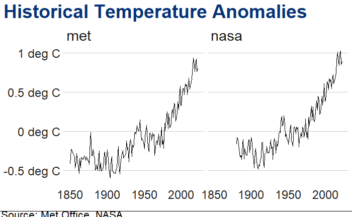

```r
dfy <- bind_rows(list(met = dfy_met, nasa = dfy_nasa), .id="id")

p <- ggplot(dfy, aes(Year, temp)) +
  geom_line() +
  facet_grid(cols=vars(id)) +
  # Title
  labs(title = "Historical Temperature Anomalies") +
  # Axis
  scale_y_continuous(labels = function(y) paste0(y, " deg C")) +
  # Style
  bbc_style() +
  theme(plot.title = element_text(color = "#063376"))

finalise_plot(p, source_name = "Source: Met Office, NASA",
              save_filepath = "imgs/temps.png",
              width_pixels = 1200, height_pixels = 800)
```

#### Fitting of Holt-Winters on annual data

Construct time series

```r
ts_met <- ts(dfy_met$temp, start=min(dfy_met$Year), frequency = 1)
ts_nasa <- ts(dfy_nasa$temp, start=min(dfy_nasa$Year), frequency = 1)
```

Create model and prediction

```r
m_met <- HoltWinters(ts_met, gamma=FALSE)
p_met <- predict(m_met, 13)

m_nasa <- HoltWinters(ts_nasa, gamma=FALSE)
p_nasa <- predict(m_nasa, 13)
```

Plot results

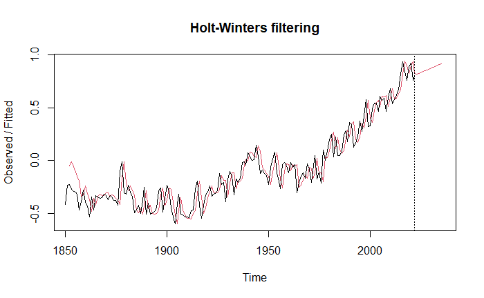

```r
plot(m_met, p_met)
```

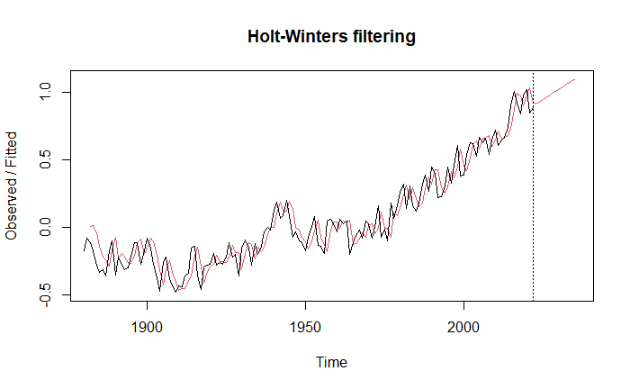

```r
plot(m_nasa, p_nasa)
```

Trend is:

```r
str_out <- paste("Temperature trend for Met Office data is:",
                 format(m_met[["coefficients"]][["b"]], digits=2),
                 "deg C")
noquote(str_out)
```

```
[1] Temperature trend for Met Office data is: 0.0084 deg C
```

```r
str_out <- paste("Temperature trend for NASA data is:",
                 format(m_nasa[["coefficients"]][["b"]], digits=2),
                 "deg C")
noquote(str_out)
```

```
[1] Temperature trend for NASA data is: 0.015 deg C
```

Interpretation: Both positive trends, with NASA being greater than Met Office

Runs test on model residuals:

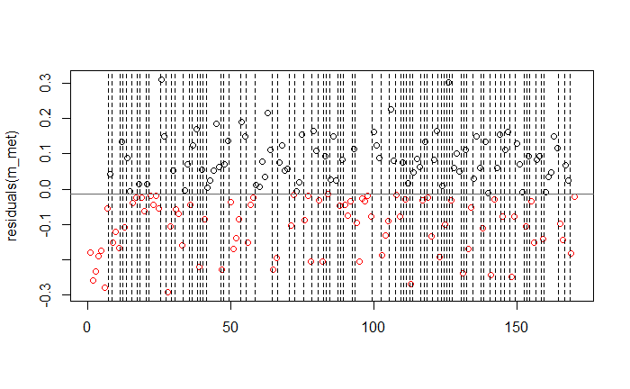

```r
rt_met <- randtests::runs.test(residuals(m_met), alternative="two.sided", plot=TRUE)
```

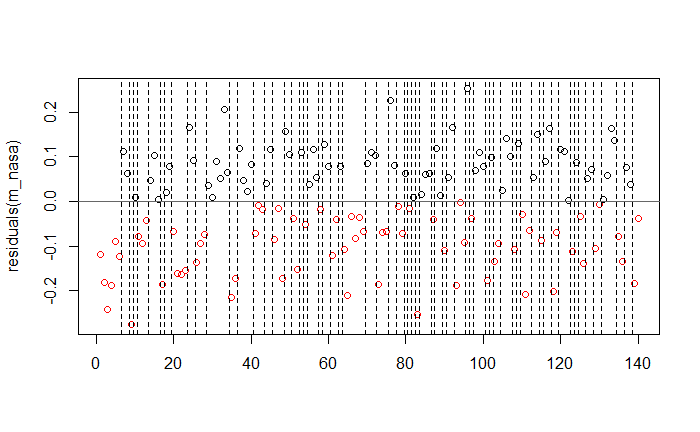

```r
rt_nasa <- randtests::runs.test(residuals(m_nasa), alternative="two.sided", plot=TRUE)
```

```r
noquote("Met Office runs tests:")
```

```
[1] Met Office runs tests:
```

```r
print_runstest(rt_met, residuals(m_met))
```

```
Number of obversations: 170
Number of runs below mean: 85
Number of runs above mean: 85
Number of runs: 83
Mean of the obversations: -0.010459
Mean value of stat test E(R): 86
Std. Dev. of the stat test StdDev(R): 6.4999
Normalized value of the stat test Z-Value: -0.46155
p-value of the stat test: 0.64441
```

```r
writeLines(c("", ""))
```

```r
noquote("NASA runs tests:")
```

```
[1] NASA runs tests:
```

```r
print_runstest(rt_nasa, residuals(m_nasa))
```

```
Number of obversations: 140
Number of runs below mean: 70
Number of runs above mean: 70
Number of runs: 65
Mean of the obversations: -0.0094841
Mean value of stat test E(R): 71
Std. Dev. of the stat test StdDev(R): 5.8948
Normalized value of the stat test Z-Value: -1.0179
p-value of the stat test: 0.30875
```

Interpretation: P-value is > 0.05, so cannot reject randomness, suggesting we have a valid model for both Met Office and NASA data

#### Looking at the trends: Are the annual changes statistically significant?

Add delta to previous year

```r
dfy_met <- dfy_met %>%
  mutate(temp_prev = lag(temp),
         temp_delta = temp - temp_prev,
         temp_prev = NULL)

dfy_nasa <- dfy_nasa %>%
  mutate(temp_prev = lag(temp),
         temp_delta = temp - temp_prev,
         temp_prev = NULL)
```

Running a one-sided t-test to see if trend is statistically significant positive

```r
tt_met <- t.test(dfy_met$temp_delta, alternative="greater")

tt_nasa <- t.test(dfy_nasa$temp_delta, alternative="greater")
```

Printing the results

```r
noquote("Met Office t-test:")
```

```
[1] Met Office t-test:
```

```r
print_ttest(tt_met, dfy_met$temp_delta)
```

```
Sample size: 172
Sample mean: 0.00709
Sample Std Dev: 0.116
Hypothesized mean: 0
Alternative hypothesis: greater
Standard error of mean: 0.00885
Degrees of freedom: 171
t-test statistic: 0.801
p-value of the stat test: 0.212
```

```r
writeLines(c("", ""))
```

```r
noquote("NASA t-test:")
```

```
[1] NASA t-test:
```

```r
print_ttest(tt_nasa, dfy_nasa$temp_delta)
```

```
Sample size: 142
Sample mean: 0.00746
Sample Std Dev: 0.111
Hypothesized mean: 0
Alternative hypothesis: greater
Standard error of mean: 0.00933
Degrees of freedom: 141
t-test statistic: 0.8
p-value of the stat test: 0.212
```

Interpretation: P-value is > 0.05, so cannot reject randomness, suggesting we have a random walk for the annual temperature increases for both the Met Office and NASA data

Doing a runs test on the temperature delta data

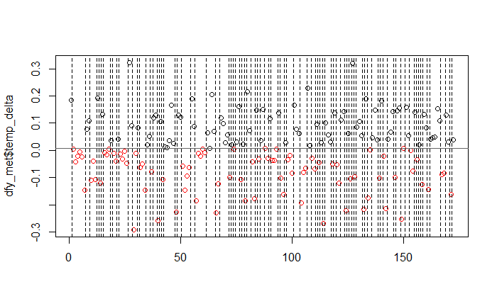

```r
rt_met_td <- randtests::runs.test(dfy_met$temp_delta, alternative="two.sided", plot=TRUE)
```

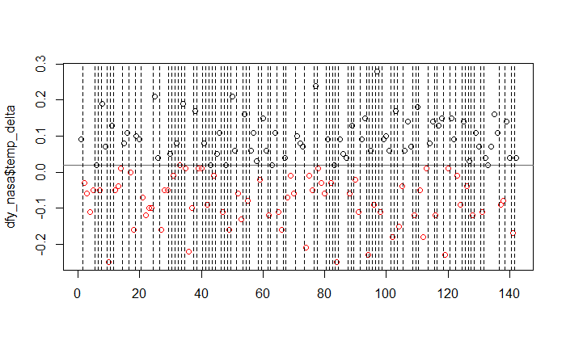

```r
rt_nasa_td <- randtests::runs.test(dfy_nasa$temp_delta, alternative="two.sided", plot=TRUE)
```

```r
noquote("Met Office runs tests:")
```

```
[1] Met Office runs tests:
```

```r
print_runstest(rt_met_td, dfy_met$temp_delta)
```

```
Number of obversations: 172
Number of runs below mean: 86
Number of runs above mean: 86
Number of runs: 93
Mean of the obversations: 0.0070869
Mean value of stat test E(R): 87
Std. Dev. of the stat test StdDev(R): 6.5382
Normalized value of the stat test Z-Value: 0.91768
p-value of the stat test: 0.35879
```

```r
writeLines(c("", ""))
```

```r
noquote("NASA runs tests:")
```

```
[1] NASA runs tests:
```

```r
print_runstest(rt_nasa_td, dfy_nasa$temp_delta)
```

```
Number of obversations: 142
Number of runs below mean: 71
Number of runs above mean: 71
Number of runs: 85
Mean of the obversations: 0.0074648
Mean value of stat test E(R): 72
Std. Dev. of the stat test StdDev(R): 5.937
Normalized value of the stat test Z-Value: 2.1897
p-value of the stat test: 0.02855
```

In both cases, the number of runs is greater than E(R), implies that there is a negative auto-correlation, i.e. warming in one year is followed by cooling in the next year.

P-value of the Met Office data is >0.05 implying randomness, but the NASA data is <0.05 implying non-randomness!

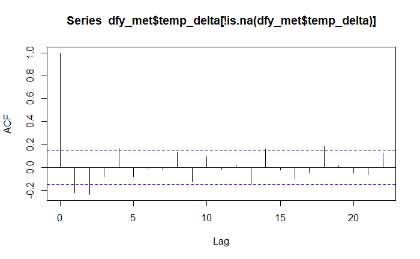

```r
acf_met <- acf(dfy_met$temp_delta[!is.na(dfy_met$temp_delta)])
```

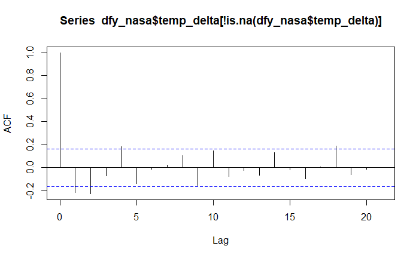

```r
acf_nasa <- acf(dfy_nasa$temp_delta[!is.na(dfy_nasa$temp_delta)])
```

The auto-correlation charts confirm the negative auto-correlation

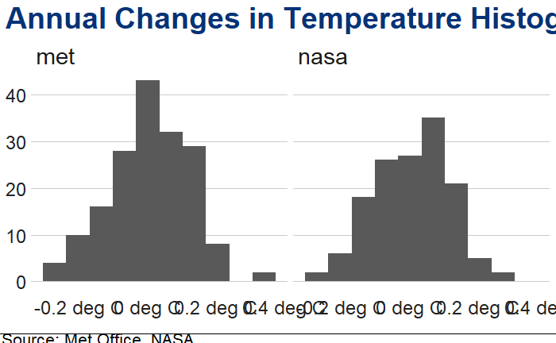

```r
dfy_rmna <- bind_rows(list(met = dfy_met, nasa = dfy_nasa), .id="id")
dfy_rmna <- filter(dfy_rmna, !is.na(temp_delta))


p <- ggplot(dfy_rmna, aes(temp_delta)) +
  geom_histogram(bins=10) +
  facet_grid(cols=vars(id)) +
  # Title
  labs(title = "Annual Changes in Temperature Histogram") +
  # Axis
  scale_x_continuous(labels = function(y) paste0(y, " deg C")) +
  # Style
  bbc_style() +
  theme(plot.title = element_text(color = "#063376"))

finalise_plot(p, source_name = "Source: Met Office, NASA",
              save_filepath = "imgs/temps_hist.png",
              width_pixels = 1200, height_pixels = 800)
```

```r
NA
NA
```

```r
skewness(dfy_met$temp_delta[!is.na(dfy_met$temp_delta)])
```

```
[1] -0.1596641
```

```r
skewness(dfy_nasa$temp_delta[!is.na(dfy_nasa$temp_delta)])
```

```
[1] -0.1769005
```

Both negative, indicating the distributions are left-skewed